# Reading and Cleaning Data with mnirs

# Introduction

Modern wearable muscle near-infrared spectroscopy (mNIRS) devices make it easier than ever to monitor local muscle oxygenation during dynamic activities.

The real challenge comes with deciding how to process, analyse, and eventually interpret those data.

The `{mnirs}` package aims to provide standardised, reproducible methods for reading, processing, and analysing mNIRS data. The goal is to help practitioners detect meaningful signal from noise, and improve our confidence in interpreting and applying information to the clients we work with.

In this vignette we will demonstrate how to:

- 📂 Read files exported from wearable mNIRS devices, and import NIRS channels into a standard data frame format with metadata, ready for further processing.
- 📊 Plot and visualise data frames of class *“mnirs”*.
- 🔍 Retrieve metadata stored with data frames of class *“mnirs”* to avoid repetitively specifying which channels to process.
- ⏱️ Resample data to a higher or lower sample rate, to correct irregular sampling periods, or to match the frequency of other data sources for synchronisation.
- 🧹 Detect and replace local outliers, invalid values, and interpolate across missing data.
- 📈️ Apply digital filtering to optimise signal-to-noise ratio for the responses observed in our data.
- ⚖️ Shift and rescale across multiple NIRS channels, to transform signal dynamic range while preserving absolute or relative scaling between muscle sites and NIRS channels.
- 🔀 Demonstrate a complete data wrangling process using pipe-friendly functions.
- 🧮 Detect and extract intervals for further analysis.

*{mnirs}* is designed to process NIRS data, but it can be used to read, clean, and process other time series data which require many of the same processing steps. Enjoy!

# 📂 Read data from file

We will read an example data file with two NIRS channels from an incremental ramp cycling assessment recorded with *Moxy* muscle oxygen monitor.

First, install and load the *{mnirs}* package and other required libraries.

*{mnirs}* can be installed with `install.packages("mnirs")`.

```r
# pak::pak("jemarnold/mnirs") ## install development version
library(ggplot2)   ## for plotting
library(mnirs)
```

The first function called will often be `read_mnirs()`. This is used to read data files exported from mNIRS devices in *.xls(x)*, *.csv*, or *.txt* formats.

Exported data files will often have multiple rows of file header metadata before the data table with NIRS recordings begins. `read_mnirs()` can extract and return this data table along with the file metadata for further processing and analysis.

See `read_mnirs()` for more details.

## `read_mnirs()`

- `file_path`

  Specify the location of the data file, including file extension. e.g. `"my_file.xlsx"`, `"C:/myfolder/my_file.csv"`, or `here::here("data", "my_file.csv")`.

> **Example data files**

> A few example data files are included in the *{mnirs}* package. File paths can be accessed with `example_mnirs()`.
- `nirs_channels`

  Multiple *NIRS* channels can be specified from the data file as a vector of names. If no `nirs_channels` are specified, `read_mnirs()` will attempt to recognise the NIRS device file format, and return the full data frame with all detected columns. This can be useful for file exploration, to find the target channel names. However, best practice is to specify the desired `nirs_channels` explicitly.
- `time_channel`

  A *time* or *sample* channel name from the data table can be specified. If left blank, the function will attempt to identify the time column automatically, however, best practice is to specify the `time_channel` explicitly.
- `event_channel`

  Optionally, a channel can be specified which indicates character *event* labels or integer *lap* values in the data table.  
  Files exported from *Artinis Oxysoft* can automatically detect `nirs_channels` from the *Legend* metadata. Names are cleaned and lowercased (e.g. *“rx1_tx1_o2hb”*). The *“Sample”* column is detected and a *“time”* column is derived as `time_channel`. `event_channel` is also automatically detected, with a secondary *“labels”* column included if present.  
  Explicitly user-supplied channel names are used to detect the data table within the file, and must match exactly with text strings in the file on the same row. We can rename these channels when reading data by specifying a named character vector:

```r
nirs_channels = c(
    renamed1 = "original_name1",
    renamed2 = "original_name2"
)
```

- `sample_rate`

  The sample rate (in Hz) of the exported data can either be specified explicitly, or it will be estimated from `time_channel`.  
  Automatic detection usually works well unless there is irregular sampling, or the `time_channel` is a count of samples rather than a time value. For example, *Oxysoft* exports a column of sample numbers rather than time values. For *Oxysoft* files specifically, the function will recognise and read the correct sample rate from the file metadata. However, in most cases `sample_rate` should be defined explicitly if known.
- `add_timestamp`

  `FALSE` by default; if `time_channel` is in date-time (POSIXct) format (e.g., *hh:mm:ss*), by default it will be converted to numeric time in seconds.  
  If `add_timestamp = TRUE`, the date-time start time value in `time_channel` or in the file metadata will be extracted and a *“timestamp”* column will be added to the returned data frame. This can be useful for synchronising devices based on system time.
- `zero_time`

  `FALSE` by default; if `time_channel` values start at a non-zero value, `zero_time = TRUE` will re-calculate time starting from zero. If `time_channel` was converted from date-time format, it will always be re-calculated from zero regardless of this option.
- `keep_all`

  `FALSE` by default; only the channels explicitly specified will be returned in a data frame. `keep_all = TRUE` will return all columns detected from the data table in the file.  
  Blank/empty columns will be omitted. Duplicate column names will be repaired by appending a suffix *“_n”*, and empty column names will be renamed as* ”col_n”*; where `n` is equal to the column number in the data file. Renamed columns should be checked to confirm correct naming if duplicates are present.
- `verbose`

  `TRUE` by default; this and most *{mnirs}* functions will return warnings and informational messages which are useful for troubleshooting and data validation. This option can be used to silence those messages. *{mnirs}* messages can be silenced globally for a session by setting `options(mnirs.verbose = FALSE)`.

```r
## {mnirs} includes sample files from a few mNIRS devices
example_mnirs()
```

```
#> [1] "artinis_intervals.xlsx"  "moxy_intervals.csv"
#> [3] "moxy_ramp.xlsx"          "pionirs_occlusion.ftn"
#> [5] "portamon_oxcap.xlsx"     "train.red_intervals.csv"
```

```r
## partial matching will error if matches multiple
try(example_mnirs("moxy"))
```

```
#> Error in example_mnirs("moxy") : ✖ Multiple files match "moxy":
#> ℹ Matching files: "moxy_intervals.csv" and "moxy_ramp.xlsx"
```

```r
## automatically detect known file formats to explore the data
read_mnirs(
    file_path = example_mnirs("artinis")
)
```

```
#> ! "Artinis" file format detected. `nirs_channels` set to vl_o2hb and vl_hhb.
#> ℹ Override by specifying `nirs_channels` explicitly.
#> ! Oxysoft `sample_rate` = 10 Hz.
#> ℹ `time_channel` = time added to the data frame, in <seconds>.
#> # A tibble: 20,920 × 5
#>     time sample event vl_o2hb vl_hhb
#>    <dbl>  <dbl> <chr>   <dbl>  <dbl>
#>  1   0        0 <NA>  -0.0289   10.7
#>  2   0.1      1 <NA>  -0.0524   10.7
#>  3   0.2      2 <NA>  -0.0916   10.7
#>  4   0.3      3 <NA>  -0.138    10.7
#>  5   0.4      4 <NA>  -0.205    10.8
#>  6   0.5      5 <NA>  -0.241    10.9
#>  7   0.6      6 <NA>  -0.257    10.9
#>  8   0.7      7 <NA>  -0.316    10.9
#>  9   0.8      8 <NA>  -0.387    10.9
#> 10   0.9      9 <NA>  -0.404    10.9
#> # ℹ 20,910 more rows
```

```r
data_raw <- read_mnirs(
    file_path = example_mnirs("moxy_ramp"), ## call an example data file
    nirs_channels = c(
        smo2_left = "SmO2 Live",    ## identify and rename channels
        smo2_right = "SmO2 Live(2)"
    ),
    time_channel = c(time = "hh:mm:ss"), ## date-time format will be converted to numeric
    event_channel = NULL,           ## leave blank if unused
    sample_rate = NULL,             ## if blank, will be estimated from time_channel
    add_timestamp = FALSE,          ## omit a date-time timestamp column
    zero_time = TRUE,               ## recalculate time values from zero
    keep_all = FALSE,               ## return only the specified data channels
    verbose = TRUE                  ## show warnings & messages
)
```

```
#> ! Estimated `sample_rate` = 2 Hz.
#> ℹ Define `sample_rate` explicitly to override.
#> Warning in read_mnirs(): ! Duplicate or irregular `time_channel` samples detected.
#> ℹ time = 211.59 and 1183.6.
#> ℹ Re-sample with `mnirs::resample_mnirs()`.
```

```r
## Note the above info message that sample_rate was estimated correctly at 2 Hz 👆
## ignore the warnings about irregular sampling for now, we will resample later

data_raw
```

```
#> # A tibble: 2,202 × 3
#>     time smo2_left smo2_right
#>    <dbl>     <dbl>      <dbl>
#>  1 0            54         68
#>  2 0.560        54         68
#>  3 1.11         54         66
#>  4 1.66         54         66
#>  5 2.21         54         66
#>  6 2.76         54         66
#>  7 3.31         57         67
#>  8 3.86         57         67
#>  9 4.41         57         67
#> 10 4.96         57         67
#> # ℹ 2,192 more rows
```

# 📊 Plot *{mnirs}* data

*{mnirs}* data can be easily viewed by calling `plot()` (explicitly documented as `plot.mnirs()`). This generic plot function uses `{ggplot2}` and will work on data frames (or lists of data frames) processed by *{mnirs}* functions, where the metadata contains `class = "mnirs"`.

> **Processing lists of *{mnirs}* data frames**

> As of *{mnirs}* `v0.7.0`, most processing functions will accept either a single data frame, a list of data frames, or a grouped data frame (requiring `{dplyr}`), and returns a single or list of data frames, respectively. This allows separate processing of NIRS interval data, e.g. filtering and shifting NIRS channels within discrete intervals, rather than on the global data frame.

## `plot.mnirs()`

- `data`

  This function takes in a data frame or list of data frames of class *“mnirs”* and returns a formatted `{ggplot2}` plot. Lists of *{mnirs}* data frames are returned as plot facets.
- `points`

  `FALSE` by default; a quick way to plot individual points for more precise sample visualisation.
- `time_labels`

  `FALSE` by default; time values on the x-axis will be plotted as numeric by default. `time_labels = TRUE` will instead plot time values as `h:mm:ss` format.
- `na.omit`

  `FALSE` by default; missing data (`NA`s) will be plotted as gaps in the time-series data. If `na.omit = TRUE`, `NA`s will be omitted from the plotted data, effectively plotting across these gaps, making them less visible, but making the general data trend easier to see if there are lots of missing values.

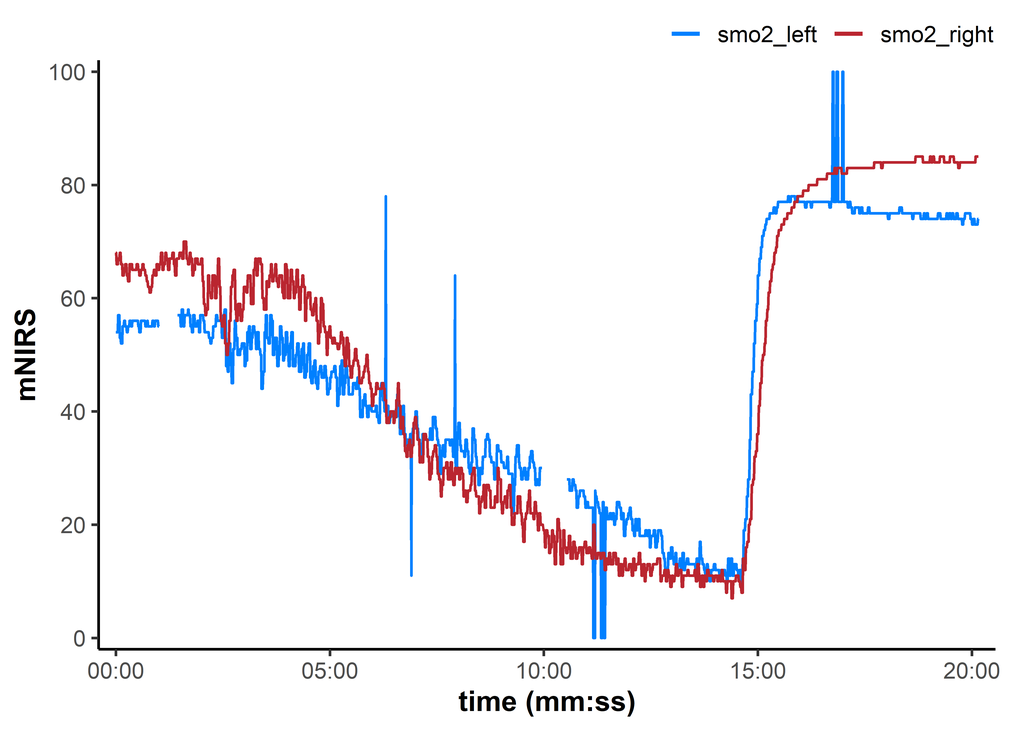

```r
## note the `time_labels` plot argument to display time values as `h:mm:ss`
plot(
    data_raw,
    points = FALSE,
    time_labels = TRUE,
    na.omit = FALSE
)
```

*{mnirs}* includes a custom `{ggplot2}` theme and colour palette available with `theme_mnirs()` and `palette_mnirs()`. See those documentation references for more details.

# 🔍 Metadata stored in *{mnirs}* data frames

Data frames generated or read by *{mnirs}* functions will return `class = "mnirs"` and contain metadata, which can be retrieved with `attributes()`.

Instead of re-defining values like our channel names or sample rate, certain *{mnirs}* functions can automatically retrieve them from metadata. They can always be overwritten manually in subsequent functions, or by using a helper function `create_mnirs_data()`.

See `create_mnirs_data()` for more details about metadata.

```r
## view metadata
attr(data_raw, "nirs_channels")
```

```
#> [1] "smo2_left"  "smo2_right"
```

```r
attr(data_raw, "time_channel")
```

```
#> [1] "time"
```

```r
attr(data_raw, "sample_rate")
```

```
#> [1] 2
```

# ⏱️ Resample data

mNIRS devices may have sample rates anywhere from 0.5 to 100+ Hz. Higher sample rates gives greater precision. However, issues can arise with irregular sampling where time samples occur at inconsistent frequencies, are repeated, or are lost. Resampling to a consistent sample rate can be used to regularise timestamps to the nearest time value according to the known data sample rate. This can make subsequent processing steps easier, as well as synchronisation with other devices.

Downsampling can be useful to reduce data size and processing requirement, although should not be used primarily as a data filtering/smoothing strategy (see **Digital filtering** section below). Upsampling can be done with interpolation over newly created samples, although caution should always be taken with creating new samples without any additional information. New samples created with resampling will be left blank (`NA`) by default.

## `resample_mnirs()`

- `data`

  This function takes in a data frame or list of data frames, applies processing to all channels specified explicitly or implicitly from *{mnirs}* metadata, then returns the processed data frame (or list). *{mnirs}* metadata will be passed to and from this function.  
  *{mnirs}* functions are also pipe-friendly for Base R 4.1+ (`|>`) or `{magrittr}` (`%>%`) pipes to chain operations together (see below).
- `time_channel`

  The column name of time series values in `data`. If the data contain *{mnirs}* metadata, this channel will be detected automatically, or it can be specified explicitly.  
  This function processes all columns in `data`, so `nirs_channels` does not need to be specified.
- `sample_rate`

  The sample rate (in Hz) of `data`. If the data contain *{mnirs}* metadata, this channel will be detected automatically, or it can be specified explicitly.
- `resample_rate`

  Resampling is specified as the desired number of samples per second (Hz). The default `resample_rate` will resample back to the existing `sample_rate` of the data. This can be useful to accommodate irregular sampling with unequal time values. Linear interpolation is used to resample `time_channel` to round values of the `sample_rate`.
- `method`

  Any new samples created by resampling (i.e. samples fill in between gaps, or up-sampled indices) can be filled in or left blank as `NA`. The default `method = "none"` leaves new samples blank, and interpolation must be explicitly specified as either *“locf”* to repeat the last observation carried forward, or *“linear”* interpolation.

```r
data_resampled <- resample_mnirs(
    data_raw,            ## blank channels will be retrieved from metadata
    time_channel = time, ## channels can be left blank or specified explicitly
    sample_rate = NULL,  ## blank by default will be retrieved from metadata
    resample_rate = 2,   ## blank by default will resample to `sample_rate`
    method = "linear"    ## linear interpolation across resampled indices
)
```

```
#> ℹ Output is resampled at 2 Hz.
```

```r
## note the altered "time" values from the original data frame 👇
data_resampled
```

```
#> # A tibble: 2,419 × 3
#>     time smo2_left smo2_right
#>    <dbl>     <dbl>      <dbl>
#>  1   0        54         68
#>  2   0.5      54         68
#>  3   1        54         66.4
#>  4   1.5      54         66
#>  5   2        54         66
#>  6   2.5      54         66
#>  7   3        55.3       66.4
#>  8   3.5      57         67
#>  9   4        57         67
#> 10   4.5      57         67
#> # ℹ 2,409 more rows
```

> **Use `resample_mnirs()` to smooth over irregular or skipped samples**

> If we see a warning from `read_mnirs()` about duplicated or irregular samples like we saw above, we can use `resample_mnirs()` to restore `time_channel` to a regular sample rate and interpolate across skipped samples.

> Note: if we perform both of these steps in a piped function call, we will still see the warning appear about irregular sampling at the end of the pipe. This warning is returned by `read_mnirs()`. But viewing the data frame can confirm that `resample_mnirs()` has resolved the issue.

# 🧹 Replace local outliers, invalid values, and missing values

We can see some data issues in the plot above, so let’s clean those with a single wrangling function `replace_mnirs()`, to prepare our data for digital filtering and smoothing.

*{mnirs}* tries to include basic functions which work on vector data, and convenience wrappers which combine functionality and can be used on multiple channels in a data frame at once.

Let’s explain the functionality of this data-wide function, and for more details about the vector-specific functions see `replace_mnirs()`.

## `replace_mnirs()`

- `nirs_channels`

  Specify which column names in `data` to process, i.e. the response variables. If the data contain *{mnirs}* metadata, these channels will be detected automatically. Channels not explicitly specified will be passed through unprocessed to the returned data frame.
- `time_channel` & `sample_rate`

  If the data contain *{mnirs}* metadata, these will be detected automatically, or they can be specified explicitly.
- `invalid_values`, `invalid_above`, or `invalid_below`

  Specific invalid values can be replaced, e.g. if a NIRS device exports `0`, `100`, or some other fixed value when signal recording is in error. If spikes or drops are present in the data, these can be replaced by specifying values above or below which to consider invalid. If left as `NULL`, no values will be replaced.
- `outlier_cutoff`

  Local outliers can be detected using a cutoff calculated from the local median value. A default value of `3` is recommended and corresponds to Pearson’s rule (i.e., ± 3 SD about the local median). If left as `NULL`, no outliers will be replaced.
- `width` or `span`

  Local outlier detection and median interpolation use a rolling local window specified by one of either `width` or `span`. `width` defines a number of samples centred around the local index being evaluated (`idx`), whereas `span` defines a range of time in units of `time_channel`.
- `method`

  Missing data (`NA`), invalid values, and local outliers specified above can be replaced via interpolation or fill methods; either *“linear”* interpolation (the default), fill with local *“median”*, or *“locf”* (*“last observation carried forward”*).  
  `NA`s can be passed through to the returned data frame with `method = "none"`. However, subsequent processing & analysis steps may return errors when `NA`s are present. Therefore, it is good practice to deal with missing data early during data processing.
- `verbose`

  As above, an option to toggle warnings and info messages.

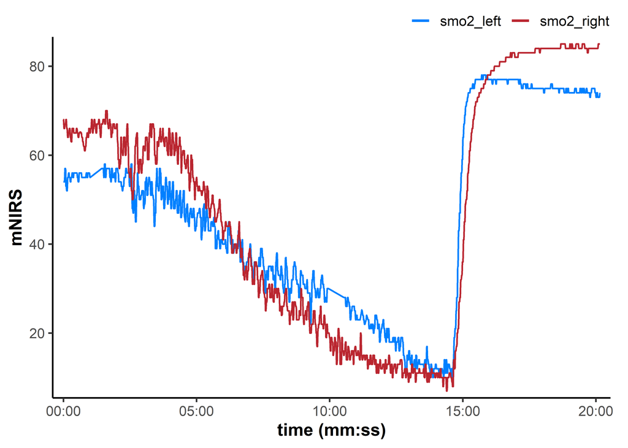

```r
data_cleaned <- replace_mnirs(
    data_resampled,     ## blank channels will be retrieved from metadata
    invalid_values = 0, ## known invalid values in the data
    invalid_above = 90, ## remove data spikes above 90
    outlier_cutoff = 3, ## recommended default value
    width = 7,          ## window to detect and replace outliers/missing values
    method = "linear"   ## linear interpolation over `NA`s
)

plot(data_cleaned, time_labels = TRUE)
```

That cleaned up all the obvious data issues.

# 📈️ Digital filtering

To improve the signal-to-noise ratio in our dataset without losing information, we should apply digital filtering to smooth the data.

## Choosing a digital filter

There are a few digital filtering methods available in *{mnirs}*. Which option is best for *you* will depend in large part on the sample rate of your data and the frequency of the response signal or phenomenon you are interested in observing.

Choosing filter parameters is an important processing step to improve signal-to-noise ratio and enhance our subsequent interpretations. Over-filtering the data can introduce data artefacts which can negatively influence signal analysis and interpretations, just as much as trying to analyse overly-noisy raw data.

It is perfectly valid to choose a digital filter by iteratively testing filter parameters until the signal or response of interest appears to be visually optimised with minimal data artefacts, to your satisfaction.

We will discuss the process of choosing a digital filter in more depth in another article coming soon.

## `filter_mnirs()`

- `na.rm`

  `FALSE` by default; `filter_mnirs()` will return an error if any missing data (`NA`) are detected in the response variables (`nirs_channels`). Setting `na.rm = TRUE` will ignore these `NA`s and pass them through to the returned data frame, but this must be opted into explicitly in this function and elsewhere.

### Smoothing-spline

- `method = "smooth_spline"`

  The default non-parametric cubic smoothing spline is often a good first filtering option when exploring the data, and works well over longer time spans. For more rapid and repeated responses, a smoothing-spline may not work as well.
- `spar`

  The smoothing parameter of the cubic spline will be determined automatically by default, or can be specified explicitly. See `stats::smooth.spline()`.

### Butterworth digital filter

- `method = "butterworth"`

  A Butterworth low-pass digital filter (specified by `type = "low"`) is probably the most common method used in mNIRS research (whether appropriately or not). For certain applications such as identifying a signal with a known frequency (e.g. cycling/running cadence or heart rate), a pass-band or a different filter type may be better suited.
- `order`

  The filter order number, specifying the number of passes the filter performs over the data. The default `order = 2` will often noticeably improve the filter over a single pass, however, higher orders above ~`4` can begin to introduce artefacts, particularly at sharp transition points.
- `W` or `fc`

  The cutoff frequency can be specified either as `W`; a fraction (between `[0, 1]`) of the [*Nyquist frequency*](https://www.youtube.com/watch?v=IZJQXlbm2dU), which is equal to half of the `sample_rate` of the data. Or as `fc`; the cutoff frequency in Hz, where this absolute frequency should still be between 0 Hz and the Nyquist frequency.
- `type`

  The filter type is specified as either `c("low", "high", "stop", "pass")`.

For filtering vector data and more details about Butterworth filter parameters, see `filter_butterworth()`.

### Moving average

- `method = "moving_average"`

  The simplest smoothing method is a moving average filter applied over a specified number of samples or time span. Commonly, this might be a 5- or 15-second centred moving average.
- `width` or `span`

  Moving average filtering occurs within a rolling local window specified by one of either `width` or `span`. `width` defines a number of samples centred around the local index being evaluated (`idx`), whereas `span` defines a range of time in units of `time_channel`.

For filtering vector data and more details about the moving average filter, see `filter_moving_average()`.

## Apply the filter

Let’s try a *Butterworth low-pass* filter, and we’ll specify some empirically chosen filter parameters for these data. See `filter_mnirs()` for further details on each of these filtering methods and their respective parameters.

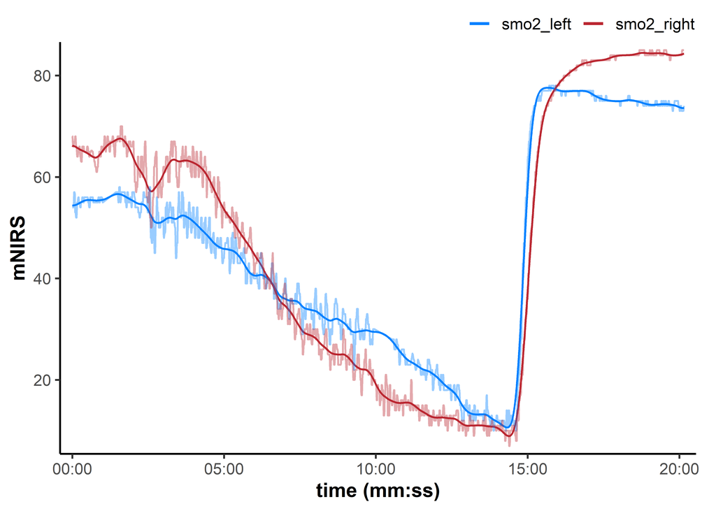

```r
data_filtered <- filter_mnirs(
    data_cleaned,           ## blank channels will be retrieved from metadata
    method = "butterworth", ## Butterworth digital filter is a common choice
    order = 2,              ## filter order number
    W = 0.02,               ## filter fractional critical frequency `[0, 1]`
    type = "low",           ## specify a "low-pass" filter
    na.rm = TRUE            ## explicitly ignore NAs
)

## we will add the non-filtered data back to the plot to compare
plot(data_filtered, time_labels = TRUE) +
    geom_line(
        data = data_cleaned,
        aes(y = smo2_left, colour = "smo2_left"), alpha = 0.4
    ) +
    geom_line(
        data = data_cleaned,
        aes(y = smo2_right, colour = "smo2_right"), alpha = 0.4
    )
```

That did a nice job reducing the high-frequency noise in our data, while preserving the sharp edges, such as the rapid reoxygenation after maximal exercise.

# ⚖️ Shift and rescale data

NIRS values are not measured on an absolute scale (arguably not even percent (%) saturation/SmO<sub>2</sub>). Therefore, we may need to adjust or calibrate our data to normalise NIRS signal values between muscle sites, individuals, trials, etc. depending on our intended comparison.

For example, we may want to set our mean baseline value to zero for all NIRS signals at the start of a recording. Or we may want to compare signal kinetics (the rate of change or time course of a response) after rescaling signal amplitudes to a common dynamic range.

These functions allow us to either shift NIRS values up or down while preserving the dynamic range (the absolute amplitude from minimum to maximum values) of our NIRS channels, or rescale the data to a new dynamic range with larger or smaller amplitude.

We can group NIRS channels together to preserve the absolute and relative scaling among certain channels, and modify that scaling between other groups of channels.

## `shift_mnirs()`

- `group_channels`

  Controls how `nirs_channels` are grouped, to preserve absolute or relative scaling. Either a character keyword or a `list()` of channel-name vectors:  
  *“ensemble”* (the default) shifts all channels together to a common value, preserving the relative scaling between channels.  
  *“distinct”* shifts each channel independently, losing the relative scaling between channels.  
  A `list()` of channel-name vectors (e.g. `list(c(A, B), c(C))`) shifts channels `A` & `B` together and `C` separately, preserving relative scaling within, but not between groups.
- `to` or `by`

  The shift amplitude can be specified by either shifting signals `to` a new value, or shifting signals `by` a fixed amplitude, given in units of the NIRS signals.
- `width` or `span`

  Shifting can be performed on the mean value within a window specified by one of either `width` or `span`. `width` defines a number of samples centred around the local index being evaluated (`idx`), whereas `span` defines a range of time in units of `time_channel`.  
  e.g. `width = 1` will shift from the single minimum sample, whereas `span = 1` would shift from the minimum mean value of all samples within one second.
- `position`

  Specifies the reference point used to shift the data; either *“min”*, *“max”*, or *“first”* sample(s).

For this data set, we want to shift each NIRS channel so that the mean of the 2-minute baseline is equal to zero, which would then give us a change in deoxygenation from baseline during the incremental cycling protocol.

> **`{tidyverse}`-style channel name specification**

> This is a good time to note that here and in most *{mnirs}* functions, data channels can be specified using `{tidyverse}`-style naming. Data frame column names can be specified either with quotes as a character string (`"smo2"`), or as a direct symbol (`smo2`).

> `{tidyselect}` support functions such as `starts_with()`, `matches()` can also be used.

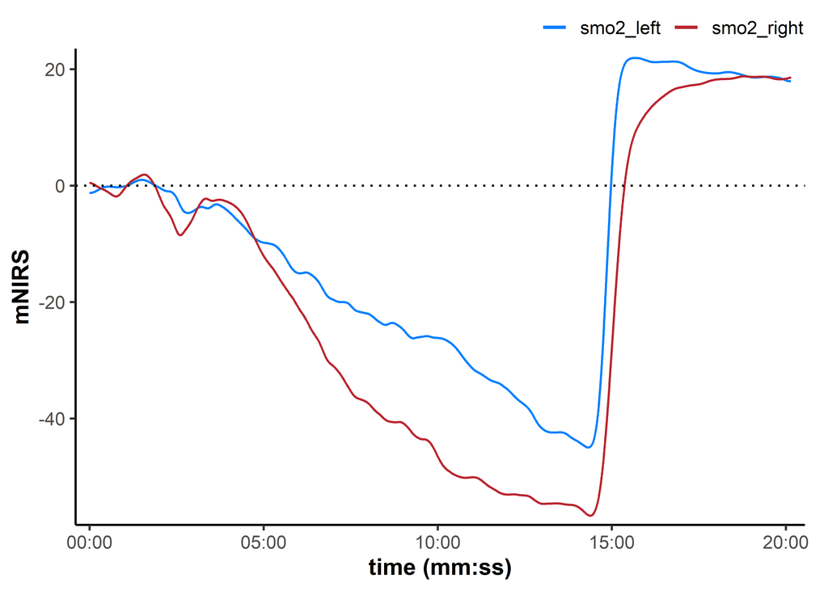

```r
data_shifted <- shift_mnirs(
    data_filtered,
    group_channels = list(smo2_left, smo2_right), ## channels shifted separately
    to = 0,            ## NIRS values will be shifted to zero
    span = 120,        ## shift the *first* 120 sec of data to zero
    position = "first"
)

plot(data_shifted, time_labels = TRUE) +
    geom_hline(yintercept = 0, linetype = "dotted")
```

Before shifting, the minimum (end of exercise) values for *“smo2_left”* and *“smo2_right”* were similar, but the starting baseline values were different.

When we shift both baseline values to zero, however, we can see that the *“smo2_left”* signal has a smaller deoxygenation amplitude compared to the *“smo2_right”* signal, and a (slightly) greater hyperaemic reoxygenation peak.

We have to consider how our assumptions and processing decisions will influence our interpretations; by shifting both starting values, we are normalising for, and implicitly assuming that the baseline represents the same starting condition for the tissues in both legs.

This may or may not be an appropriate assumption for your research question; for example, this may be appropriate when we are more interested in the relative change (delta) in each leg during an intervention or exposure (often referred to as *“∇SmO2”*), but not if we were interested in asymmetries that could influence SmO<sub>2</sub> at rest.

## `rescale_mnirs()`

We may also want to rescale our data to a new dynamic range, changing the signal amplitude.

- `group_channels`

  Controls how `nirs_channels` are grouped, to preserve absolute or relative scaling. Either a character keyword or a `list()` of channel-name vectors:  
  *“ensemble”* (the default) rescales all channels together to a common range, preserving the relative scaling between channels.  
  *“distinct”* rescales each channel independently, losing the relative scaling between channels.  
  A `list()` of channel-name vectors (e.g. `list(c(A, B), c(C))`) rescales channels `A` & `B` together and `C` separately, preserving relative scaling within, but not between groups.
- `range`

  Specifies the new dynamic range in the form `c(min, max)`. For example, if we want to calibrate each NIRS signal to its own observed ‘functional range’ during exercise, we could rescale them to 0-100%.

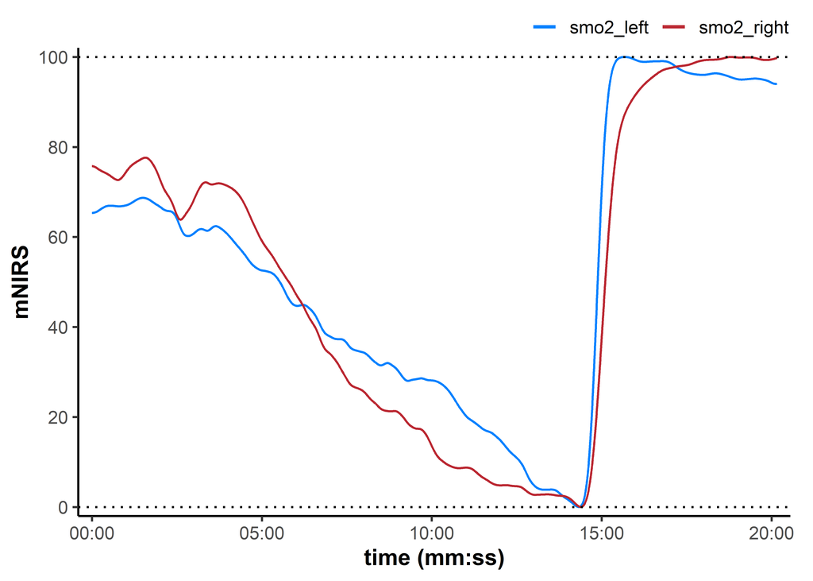

```r
data_rescaled <- rescale_mnirs(
    data_filtered,
    group_channels = list(smo2_left, smo2_right), ## channels rescaled separately
    range = c(0, 100) ## rescale to a 0-100% functional exercise range
)

plot(data_rescaled, time_labels = TRUE) +
    geom_hline(yintercept = c(0, 100), linetype = "dotted")
```

Here, our assumption is that during a maximal exercise task, the minimum and maximum values represent the functional capacity of each tissue volume being observed. So we rescale the functional dynamic range in each leg.

By normalising this way, we might lose meaningful differences captured by the different amplitudes between *“smo2_left”* and *“smo2_right”*, but we might be more interested in the trend or time course of each response.

Our interpretation may be that *“smo2_right”* appears to start at a slightly higher percent of its functional range, deoxygenates faster toward a minimum, and reaches a quasi-plateau near maximal exercise. While *“smo2_left”* deoxygenates slightly slower and continues to deoxygenate until maximal task tolerance.

Additionally, the left leg reoxygenates slightly faster than the right during recovery. This might, for example, indicate exercise capacity differences between the limbs (although these differences are marginal and only discussed as representative for influence on interpretations).

# 🔀 Pipe-friendly functions

Most *{mnirs}* functions can be piped together using Base R 4.1+ (`|>`) or `{magrittr}` (`%>%`). The entire processing workflow can easily be performed in a sequential pipe.

To demonstrate this, we’ll read a different example file recorded with *Train.Red FYER* muscle oxygen sensor and pipe it through each processing stage straight to a plot.

This is also a good time to demonstrate how to use the global `mnirs.verbose` option to silence all warning & information messages, for example when dealing with a familiar dataset. We recommend leaving `verbose = TRUE` by default whenever reading and exploring a new file.

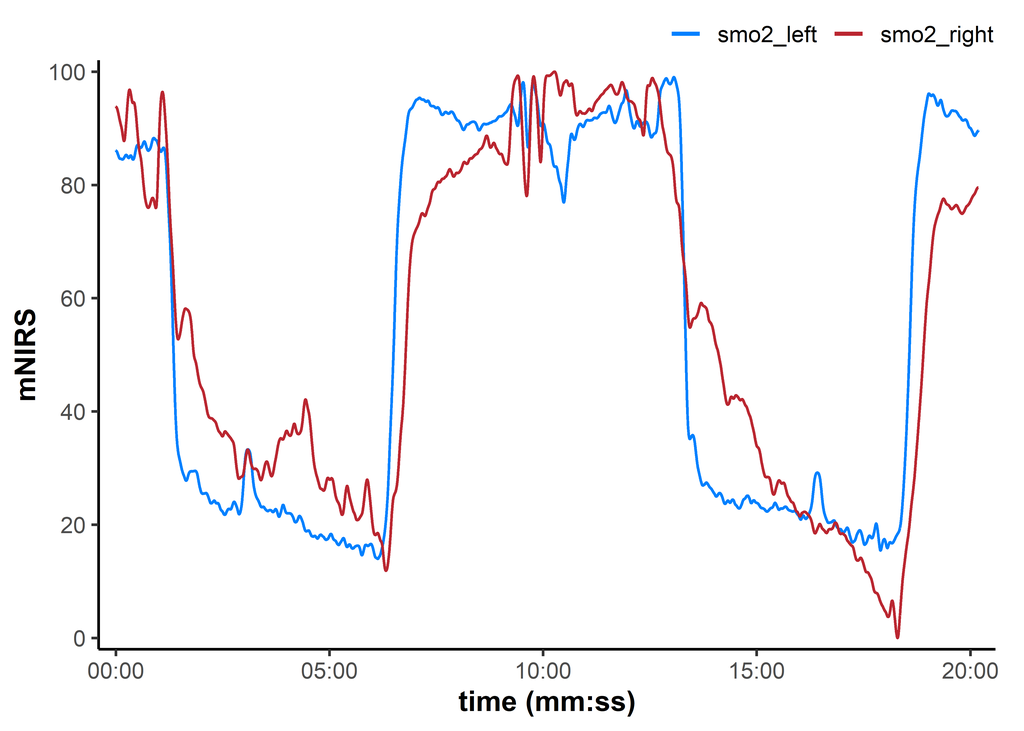

```r
options(mnirs.verbose = FALSE)

nirs_data <- read_mnirs(
    example_mnirs("train.red"),
    nirs_channels = c(
        smo2_left = "SmO2 unfiltered",
        smo2_right = "SmO2 unfiltered"
    ),
    time_channel = c(time = "Timestamp (seconds passed)"),
    zero_time = TRUE
) |>
    resample_mnirs(method = "linear") |> ## default settings will resample to the same `sample_rate`
    replace_mnirs(
        invalid_above = 73,
        outlier_cutoff = 3,
        span = 7
    ) |>
    filter_mnirs(
        method = "butterworth",
        order = 2,
        W = 0.02,
        na.rm = TRUE
    ) |>
    shift_mnirs(
        group_channels = list(smo2_left, smo2_right), ## 👈 channels grouped separately
        to = 0,
        span = 60,
        position = "first"
    ) |>
    rescale_mnirs(
        group_channels = list(c(smo2_left, smo2_right)), ## 👈 channels grouped together
        range = c(0, 100)
    )

plot(nirs_data, time_labels = TRUE)
```

We have two exercise intervals in this data set. Let’s demonstrate some of the common analysis methods currently available with *{mnirs}*.

# 🧮 Interval extraction

After the NIRS signal has been cleaned and filtered, it should be ready for further processing and analysis.

*{mnirs}* is under development to include functionality for processing discrete intervals and events, e.g. reoxygenation kinetics, slope calculations for post-occlusion microvascular responsiveness, and critical oxygenation breakpoints.